# notebookwfhimpactonburnout slides

"Allow Working From Home Will Decrease Employee's Burn Out Rate"

Background:

Our company recently did a survey about Career, work environment and well-being on questions such as:

I’m able to manage my work in a way that allows me to maintain a healthy balance between work and home I believe that my health and well-being is a priority As a long time employee, I have a feel about the numbers collected and suspected that one of the factors that has causal connection is WFH setup. Using "https://www.kaggle.com/datasets/blurredmachine/are-your-employees-burning-out" as a model dataset, specifically the train.csv table, I have conducted few tests/plots to test out below hypothesis.

Hypothesis and analysis:

My hypothesis is that allow WFH will have lower Mental Fatigue Score and Burn Rate, which will translate into higher number on work/home balance and health/well-being as a priority suvey results.

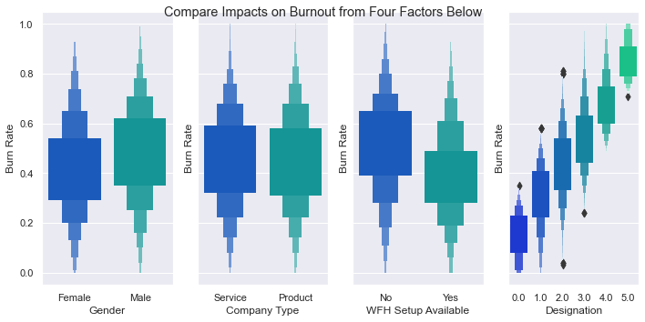

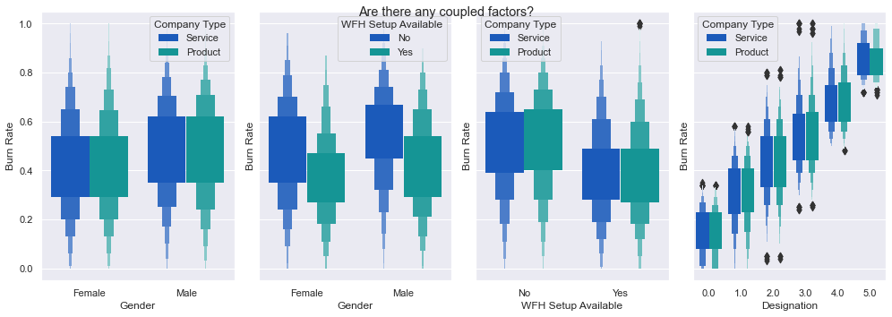

```
Let's see the Burn Out mean values with WFH and No WFH:
Burn Out Rate - With WFH: 0.39630309072781417
Burn Out Rate - No WFH: 0.5182266355140233
```

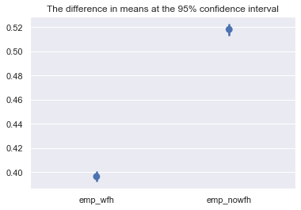

```
Using TTest to evaluate WFH and No-WFH impacts on Burn Out differently
Ttest_indResult(statistic=-44.00613323235241, pvalue=0.0)

Both the confidence interval figure and the TTest results show the significant impact of WFH setups on Burn Out
```

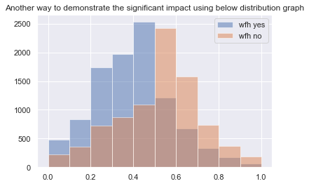

Findings and Recommendations:

Present the results to our HP and ask them to conduct similar suvey and create a hyper-brid working model that will be good for both company and it's empolyees. Also ask HR to think about how they can remotivate long term employees and provide reskill trainings so they can do something new.